# Coursera Practical Machine Learning-Case study

Bingjing GU

## Background

Using devices such as Jawbone Up, Nike FuelBand, and Fitbit it is now possible to collect a large amount of data about personal activity relatively inexpensively. These type of devices are part of the quantified self movement – a group of enthusiasts who take measurements about themselves regularly to improve their health, to find patterns in their behavior, or because they are tech geeks. One thing that people regularly do is quantify how much of a particular activity they do, but they rarely quantify how well they do it. In this project, your goal will be to use data from accelerometers on the belt, forearm, arm, and dumbell of 6 participants. They were asked to perform barbell lifts correctly and incorrectly in 5 different ways. More information is available from the website here: http://groupware.les.inf.puc-rio.br/har (see the section on the Weight Lifting Exercise Dataset).

## Data

The training data for this project are available here:

https://d396qusza40orc.cloudfront.net/predmachlearn/pml-training.csv

The test data are available here:

https://d396qusza40orc.cloudfront.net/predmachlearn/pml-testing.csv

The data for this project come from this source: http://groupware.les.inf.puc-rio.br/har.

## Data Preparation

we first load those packages I would use in this case project.

```r
library(caret)
library(rattle)
library(randomForest)
library(rpart)
library(rpart.plot)
library(C50)
library(plyr)
```

Then we read the train set and test set. There are 19622 observations and 160 variables which means the first step is to reduce the variables since there are too many variables there and some of them are multicollinearity and useless on prediction power. The first step I would do is to drop those variables contain NA values. After that we remove those “near-zero-variance” predictors which need to be identified and eliminated before modeling. At last, we remove those meaningless features for prediction, such as first several columns. Now there are 54 columns remaining, one is the outcome classe. others are the features. The test set need the same features as the train set.

```r
train <- read.table("pml-training.csv",header=T,sep=",")
test <- read.table("pml-testing.csv",header=T,sep=",")
train <- train[, colSums(is.na(train)) == 0]
nzv_cols <- nearZeroVar(train)
if(length(nzv_cols) > 0) train <- train[, -nzv_cols]
train <- train[, -(1:5)]
idx <- match(names(train), names(test))
idx  <- idx [!is.na(idx )]
test <- test[,idx]
set.seed(2017)
intrain <- createDataPartition(train$classe, p = 0.8, list = FALSE)
train <- train[intrain, ]
valid <- train[-intrain, ]
```

## Algorithm Models

### Classification Trees

In the begining, I use the classification trees to predict the outcomes and check the performance of it.

```r
control <- trainControl(method = "cv", number = 10)
rpart <- train(classe ~ ., data = train, method = "rpart", trControl = control)
print(rpart)
```

```
## CART
##
## 15699 samples
##    53 predictor
##     5 classes: 'A', 'B', 'C', 'D', 'E'
##
## No pre-processing
## Resampling: Cross-Validated (10 fold)
## Summary of sample sizes: 14128, 14128, 14130, 14130, 14129, 14130, ...
## Resampling results across tuning parameters:
##
##   cp          Accuracy   Kappa
##   0.03956386  0.5388926  0.40923494
##   0.05948672  0.4287498  0.23044647
##   0.11686693  0.3322421  0.07303721
##
## Accuracy was used to select the optimal model using  the largest value.
## The final value used for the model was cp = 0.03956386.
```

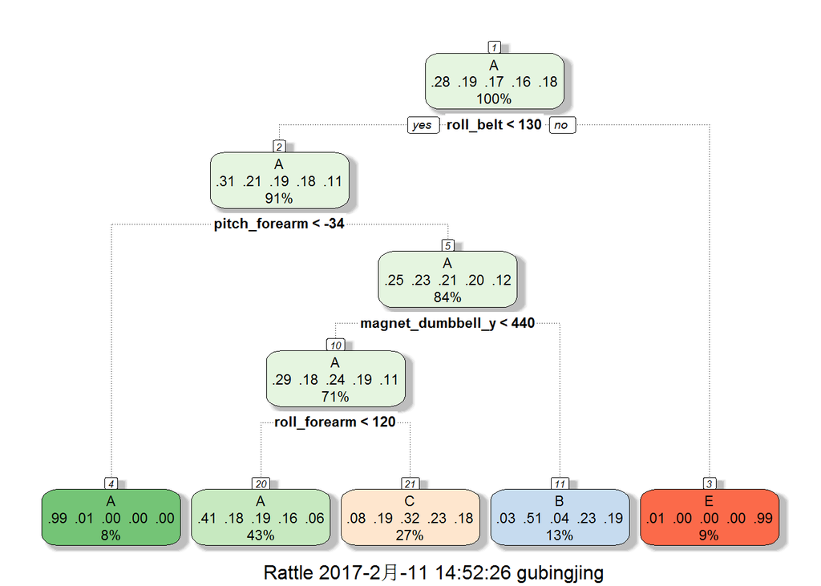

```r
fancyRpartPlot(rpart$finalModel)
```

```r
predict.rpart <- predict(rpart, valid)
conf.rpart <- confusionMatrix(valid$classe, predict.rpart)
accuracy.rpart <- conf.rpart$overall[1]
```

we start a 10-fold cross validation to fit the classification trees and get the accuracy $0.477707$ on the validation set. It’s not a quite good results on test set. The out of sample error is around 53%. The performance on train set is also bad. These imply that it would not be overfitting and underfitting. The method itself is not the best choice. So we need another method to substitute it.

### Random Forests

```r
control <- trainControl(method = "cv", number = 10)
rf <- train(classe ~ ., data = train, method = "rf", trControl = control)
print(rf)
```

```
## Random Forest
##
## 15699 samples
##    53 predictor
##     5 classes: 'A', 'B', 'C', 'D', 'E'
##
## No pre-processing
## Resampling: Cross-Validated (10 fold)
## Summary of sample sizes: 14129, 14129, 14130, 14130, 14129, 14129, ...
## Resampling results across tuning parameters:
##
##   mtry  Accuracy   Kappa
##    2    0.9954779  0.9942798
##   27    0.9978982  0.9973415
##   53    0.9959874  0.9949241
##
## Accuracy was used to select the optimal model using  the largest value.
## The final value used for the model was mtry = 27.
```

```r
predict.rf <- predict(rf, valid)
conf.rf <- confusionMatrix(valid$classe, predict.rf)
accuracy.rf <- conf.rf$overall[1]
```

### Boosting trees

```r
control <- trainControl(method = "cv", number = 10)
grid <- expand.grid(.model = "tree",.trials = c(1:100),.winnow = FALSE)
c5 <- train(classe ~ ., data = train,method = "C5.0",tuneGrid = grid,trControl = control)
predict.c5 <- predict(c5, valid)
conf.c5 <- confusionMatrix(valid$classe, predict.c5)
accuracy.c5 <- conf.c5$overall[1]
```

### Application in Test set

Random forests and Boosting trees are far more better than claasification trees. We implement these two complicated methods based on claasification trees.

```r
predict(rf, test)
```

```
##  [1] B A B A A E D B A A B C B A E E A B B B
## Levels: A B C D E
```

```r
predict(c5, test)
```

```
##  [1] B A B A A E D B A A B C B A E E A B B B
## Levels: A B C D E
```

These two methods also give totally same results on the test set.